# hw2

Min Jegal, Alba Arribas

2023-12-24

# Classification and regression

For this assignment we are using a wine database https://archive.ics.uci.edu/dataset/186/wine+quality. This database is divided in two, both of them with the same 12 variables. We have the red and white database which later on we will combine. this database consist on the following values:

**fixed acidity** : most acids involved with wine or fixed or nonvolatile (do not evaporate readily)

**volatile acidity** : the amount of acetic acid in wine, which at too high of levels can lead to an unpleasant, vinegar taste

**citric acid** : found in small quantities, citric acid can add ‘freshness’ and flavor to wines

**chlorides** : the amount of salt in the wine

**density** : the density of water is close to that of water depending on the percent alcohol and sugar content

**alcohol sulfur dioxide** : the percent alcohol content of the wine

**quality** : output variable (based on sensory data, score between 0 and 10)

So our main goal here will be to determine which of this factors affect the wine the most and how it differs from one wine type to another.

```r
#setwd("A:/AI_STUDY/Practice/2023-2024 MADRID/Statistical Learning/HW2/Statistical-Learning_Wine/wine+quality")
white_wine = read.csv(file = "winequality-white.csv", header=T, sep=";", dec=".")
red_wine = read.csv(file = "winequality-red.csv", header=T, sep=";", dec=".")
head(white_wine)
```

```
##   fixed.acidity volatile.acidity citric.acid residual.sugar chlorides
## 1           7.0             0.27        0.36           20.7     0.045
## 2           6.3             0.30        0.34            1.6     0.049
## 3           8.1             0.28        0.40            6.9     0.050
## 4           7.2             0.23        0.32            8.5     0.058
## 5           7.2             0.23        0.32            8.5     0.058
## 6           8.1             0.28        0.40            6.9     0.050
##   free.sulfur.dioxide total.sulfur.dioxide density   pH sulphates alcohol
## 1                  45                  170  1.0010 3.00      0.45     8.8
## 2                  14                  132  0.9940 3.30      0.49     9.5
## 3                  30                   97  0.9951 3.26      0.44    10.1
## 4                  47                  186  0.9956 3.19      0.40     9.9
## 5                  47                  186  0.9956 3.19      0.40     9.9
## 6                  30                   97  0.9951 3.26      0.44    10.1
##   quality
## 1       6
## 2       6
## 3       6
## 4       6
## 5       6
## 6       6
```

Here, we combine both databases adding new column called type with a categorical variable indicating if the wine is red or white.

```r
white_wine$type <- "white"
red_wine$type <- "red"

# Combine the two dataframes
wine.df <- rbind(white_wine, red_wine)
head(wine.df)
```

```
##   fixed.acidity volatile.acidity citric.acid residual.sugar chlorides
## 1           7.0             0.27        0.36           20.7     0.045
## 2           6.3             0.30        0.34            1.6     0.049
## 3           8.1             0.28        0.40            6.9     0.050
## 4           7.2             0.23        0.32            8.5     0.058
## 5           7.2             0.23        0.32            8.5     0.058
## 6           8.1             0.28        0.40            6.9     0.050
##   free.sulfur.dioxide total.sulfur.dioxide density   pH sulphates alcohol
## 1                  45                  170  1.0010 3.00      0.45     8.8
## 2                  14                  132  0.9940 3.30      0.49     9.5
## 3                  30                   97  0.9951 3.26      0.44    10.1
## 4                  47                  186  0.9956 3.19      0.40     9.9
## 5                  47                  186  0.9956 3.19      0.40     9.9
## 6                  30                   97  0.9951 3.26      0.44    10.1
##   quality  type
## 1       6 white
## 2       6 white
## 3       6 white
## 4       6 white
## 5       6 white
## 6       6 white
```

```r
summary(wine.df)
```

```
##  fixed.acidity    volatile.acidity  citric.acid     residual.sugar
##  Min.   : 3.800   Min.   :0.0800   Min.   :0.0000   Min.   : 0.600
##  1st Qu.: 6.400   1st Qu.:0.2300   1st Qu.:0.2500   1st Qu.: 1.800
##  Median : 7.000   Median :0.2900   Median :0.3100   Median : 3.000
##  Mean   : 7.215   Mean   :0.3397   Mean   :0.3186   Mean   : 5.443
##  3rd Qu.: 7.700   3rd Qu.:0.4000   3rd Qu.:0.3900   3rd Qu.: 8.100
##  Max.   :15.900   Max.   :1.5800   Max.   :1.6600   Max.   :65.800
##    chlorides       free.sulfur.dioxide total.sulfur.dioxide    density
##  Min.   :0.00900   Min.   :  1.00      Min.   :  6.0        Min.   :0.9871
##  1st Qu.:0.03800   1st Qu.: 17.00      1st Qu.: 77.0        1st Qu.:0.9923
##  Median :0.04700   Median : 29.00      Median :118.0        Median :0.9949
##  Mean   :0.05603   Mean   : 30.53      Mean   :115.7        Mean   :0.9947
##  3rd Qu.:0.06500   3rd Qu.: 41.00      3rd Qu.:156.0        3rd Qu.:0.9970
##  Max.   :0.61100   Max.   :289.00      Max.   :440.0        Max.   :1.0390
##        pH          sulphates         alcohol         quality
##  Min.   :2.720   Min.   :0.2200   Min.   : 8.00   Min.   :3.000
##  1st Qu.:3.110   1st Qu.:0.4300   1st Qu.: 9.50   1st Qu.:5.000
##  Median :3.210   Median :0.5100   Median :10.30   Median :6.000
##  Mean   :3.219   Mean   :0.5313   Mean   :10.49   Mean   :5.818
##  3rd Qu.:3.320   3rd Qu.:0.6000   3rd Qu.:11.30   3rd Qu.:6.000
##  Max.   :4.010   Max.   :2.0000   Max.   :14.90   Max.   :9.000
##      type
##  Length:6497
##  Class :character
##  Mode  :character
##
##
##
```

```r
dim(wine.df)
```

```
## [1] 6497   13
```

```r
str(wine.df)
```

```
## 'data.frame':    6497 obs. of  13 variables:
##  $ fixed.acidity       : num  7 6.3 8.1 7.2 7.2 8.1 6.2 7 6.3 8.1 ...
##  $ volatile.acidity    : num  0.27 0.3 0.28 0.23 0.23 0.28 0.32 0.27 0.3 0.22 ...
##  $ citric.acid         : num  0.36 0.34 0.4 0.32 0.32 0.4 0.16 0.36 0.34 0.43 ...
##  $ residual.sugar      : num  20.7 1.6 6.9 8.5 8.5 6.9 7 20.7 1.6 1.5 ...
##  $ chlorides           : num  0.045 0.049 0.05 0.058 0.058 0.05 0.045 0.045 0.049 0.044 ...
##  $ free.sulfur.dioxide : num  45 14 30 47 47 30 30 45 14 28 ...
##  $ total.sulfur.dioxide: num  170 132 97 186 186 97 136 170 132 129 ...
##  $ density             : num  1.001 0.994 0.995 0.996 0.996 ...
##  $ pH                  : num  3 3.3 3.26 3.19 3.19 3.26 3.18 3 3.3 3.22 ...
##  $ sulphates           : num  0.45 0.49 0.44 0.4 0.4 0.44 0.47 0.45 0.49 0.45 ...
##  $ alcohol             : num  8.8 9.5 10.1 9.9 9.9 10.1 9.6 8.8 9.5 11 ...
##  $ quality             : int  6 6 6 6 6 6 6 6 6 6 ...
##  $ type                : chr  "white" "white" "white" "white" ...
```

Now we check if there are any missing values.

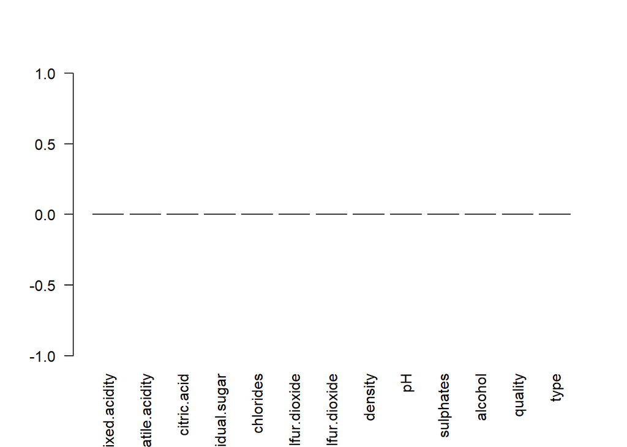

```r
barplot(colMeans(is.na(wine.df)), las=2)
```

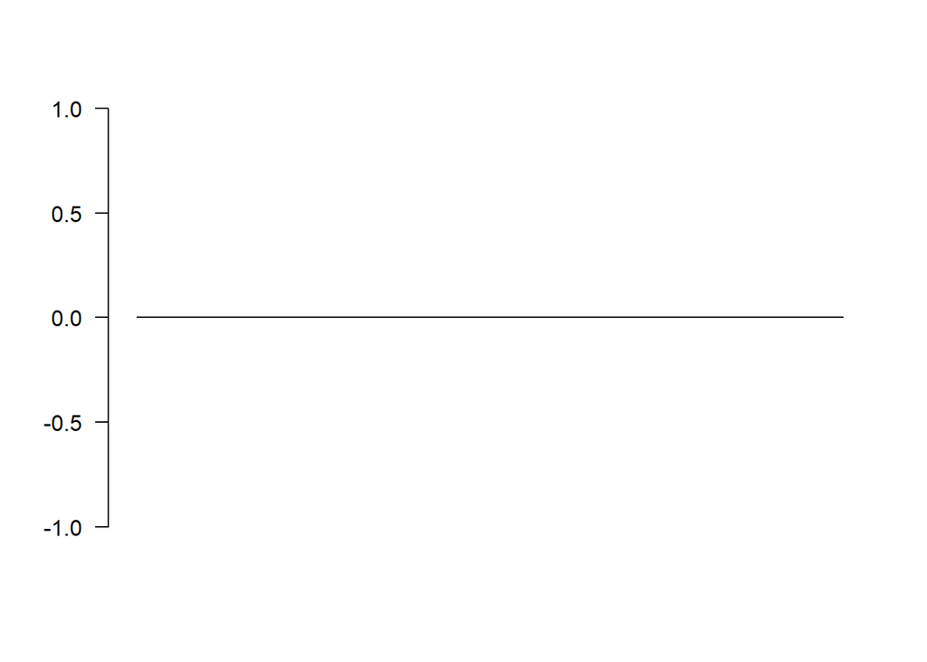

```r
barplot(c(any(is.na(wine.df))), las=2)
```

Seems like there is no NAs. After that, we check for any outliers. Thinking of the data, the outliers will detect few excellent or poor wines.

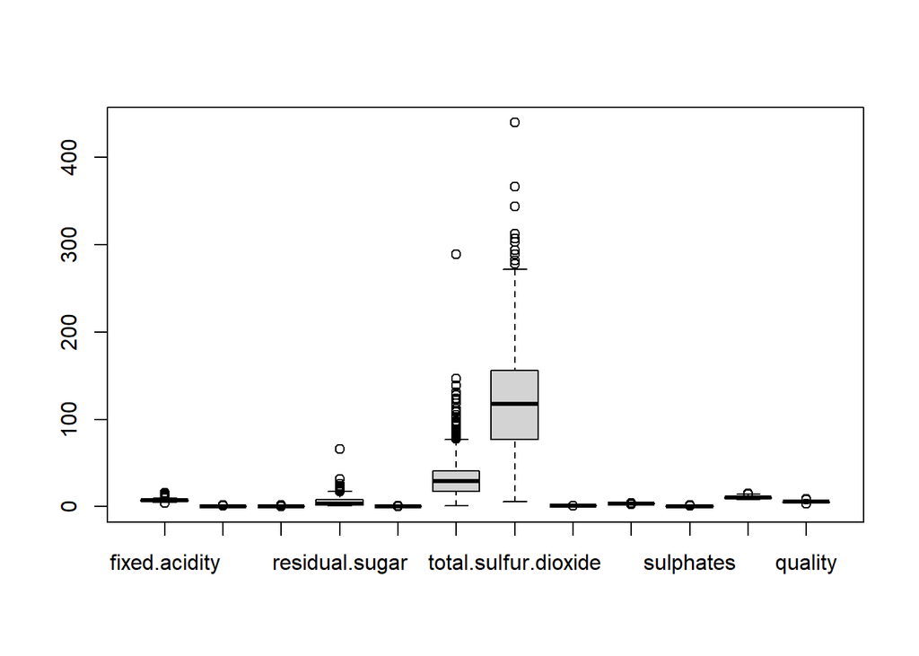

[output not shown]

[output cut: 302 more lines]

```r
library(outliers)
boxplot(subset(wine.df, select = -c(13)))$out
```

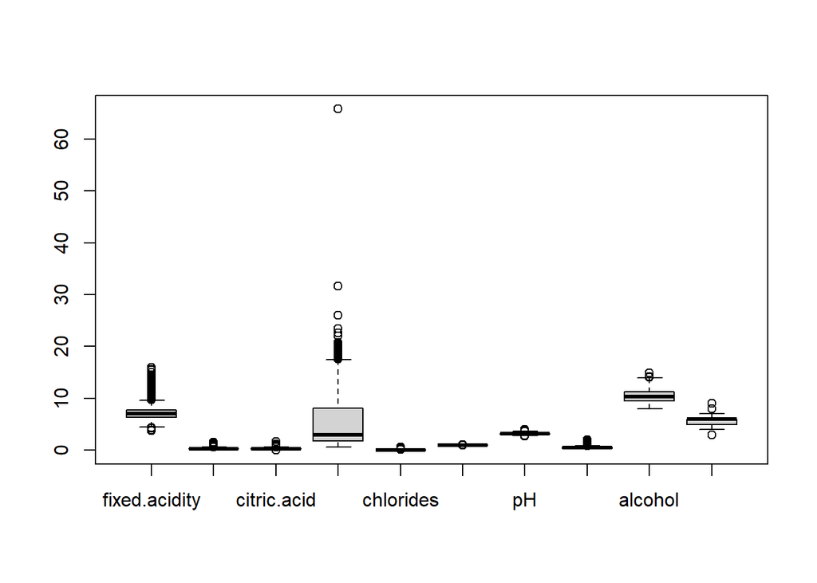

[output not shown]

[output cut: 254 more lines]

```r
boxplot(subset(wine.df, select = -c(6,7,13)))$out
```

We can see that there are not negative values and the outliers we have might indicate that a wine is specially good or specially bad therefore getting rid of them will result in a loss of information. Therefore, to handle this outliers we could just standardize the code so it minimizes the distortion.

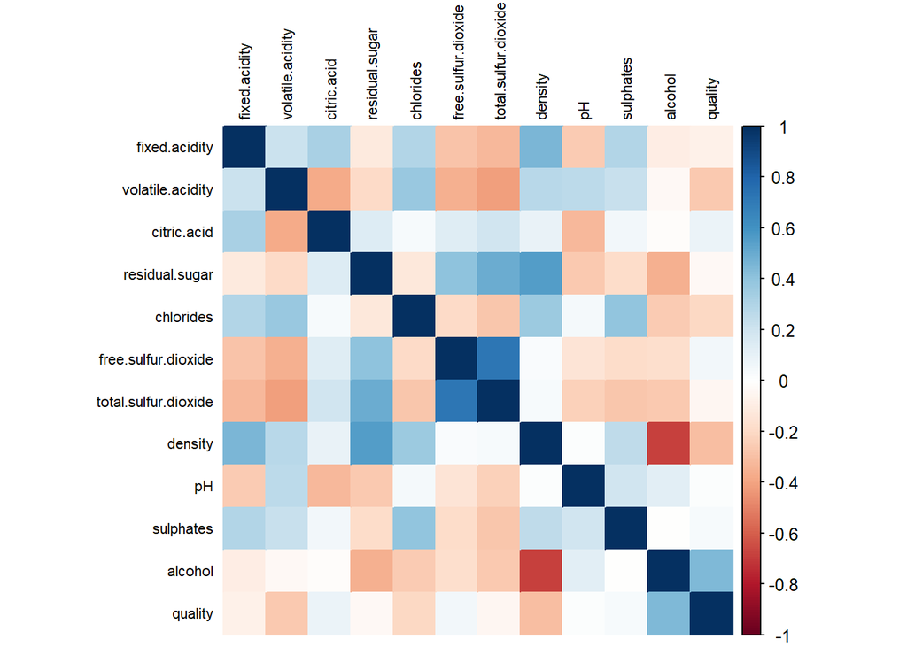

```r
library(corrplot)
correlation_matrix <- cor(wine.df[, -which(names(wine.df) == "type")])
corrplot(correlation_matrix, method = "color", tl.cex = 0.7, tl.col = "black", addrect = 2)
```

## Classification

Quality Prediction : to predict the quality of the wine based on its physicochemical properties.

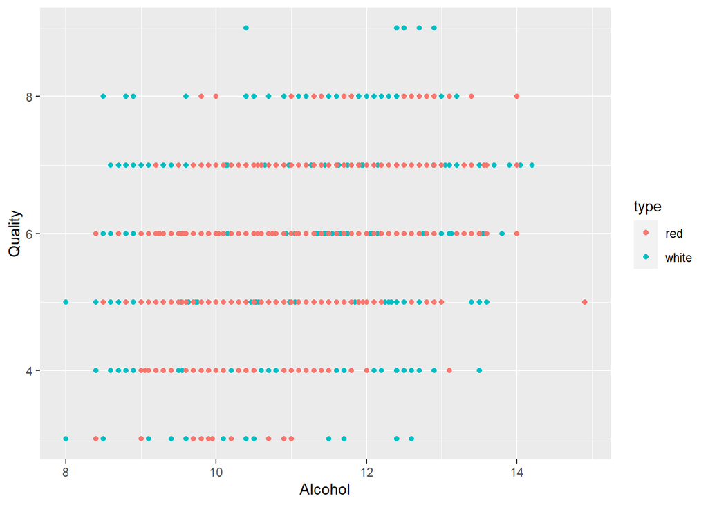

```r
library(ggplot2)
library(lmtest)
ggplot(wine.df, aes(x = alcohol, y = quality, color = type)) +
  geom_point() +
  labs(x = "Alcohol", y = "Quality")
```

According to the chart, it seems like the mid ragned quailty wines (5 - 7) shows a big variablity on the strongness of Alcohol, however, the low quality wines have lower Alcohol than the high quality wines.

### Distribution charts

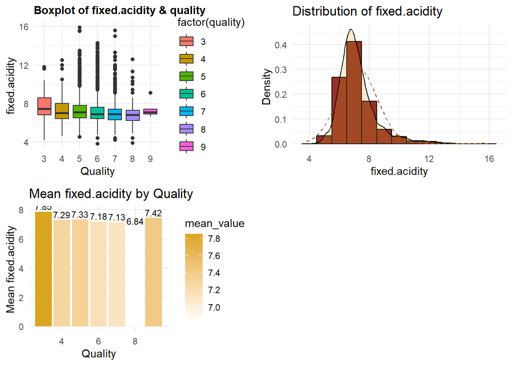

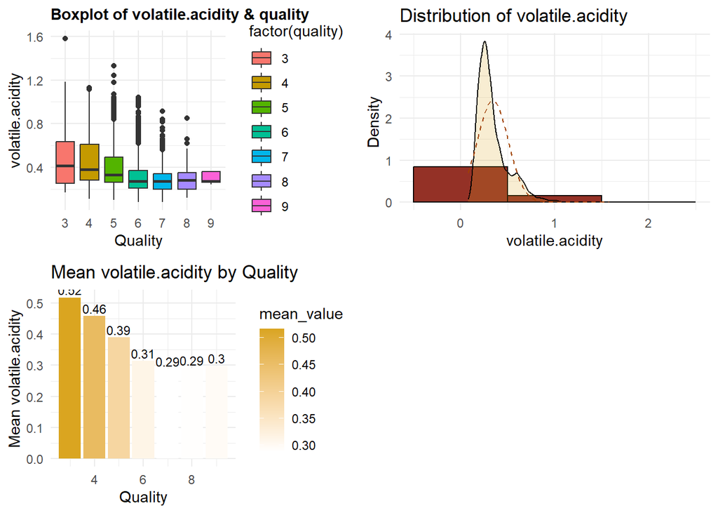

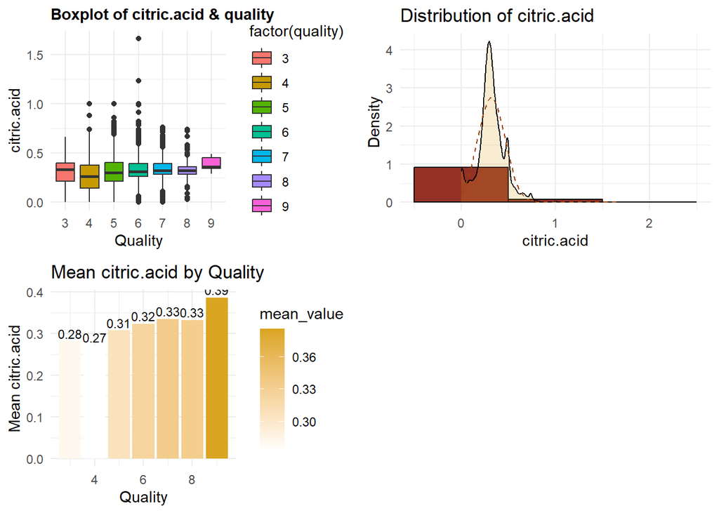

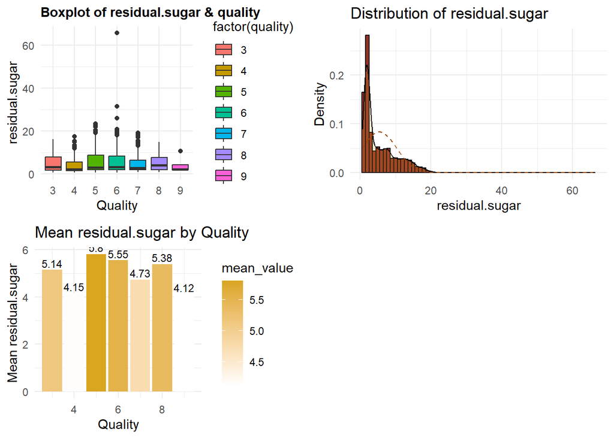

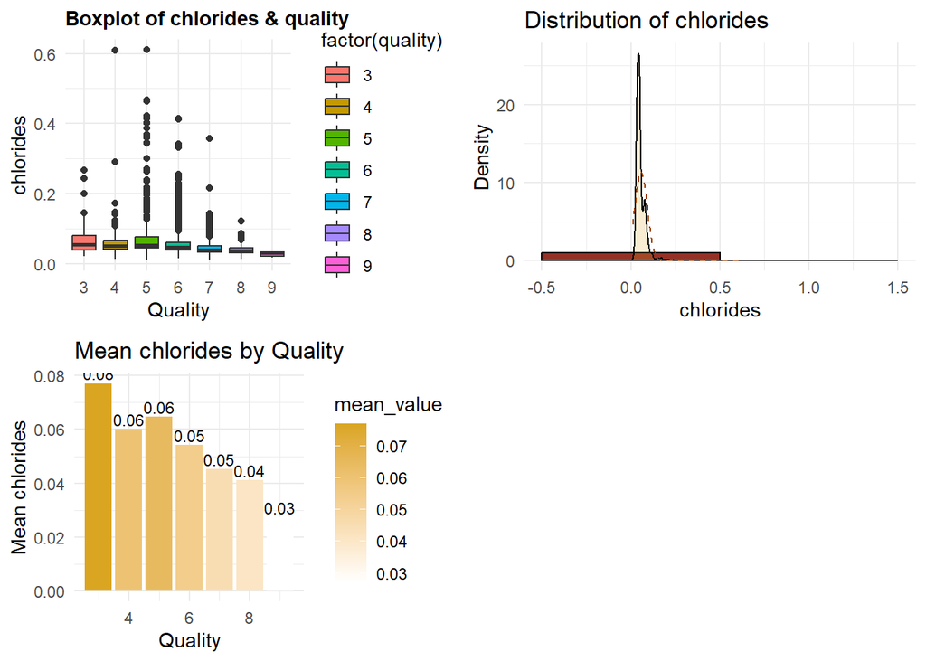

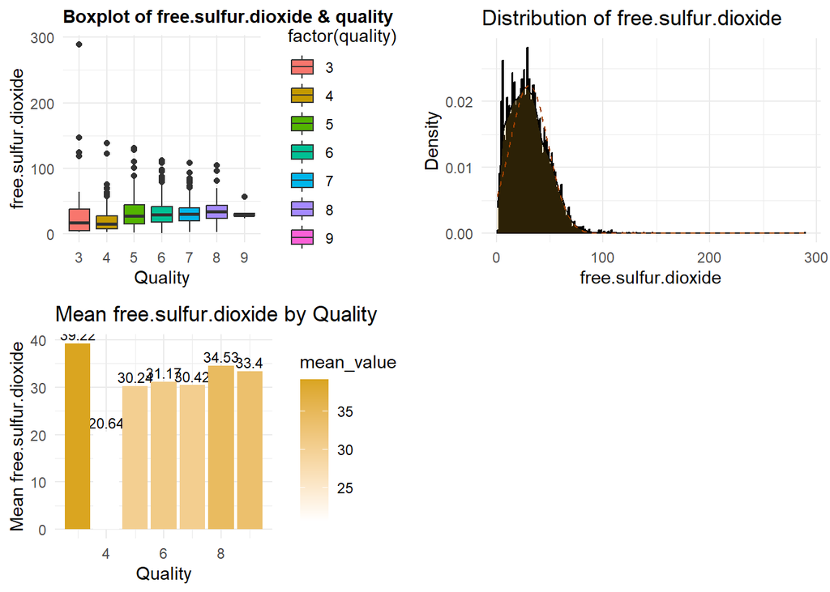

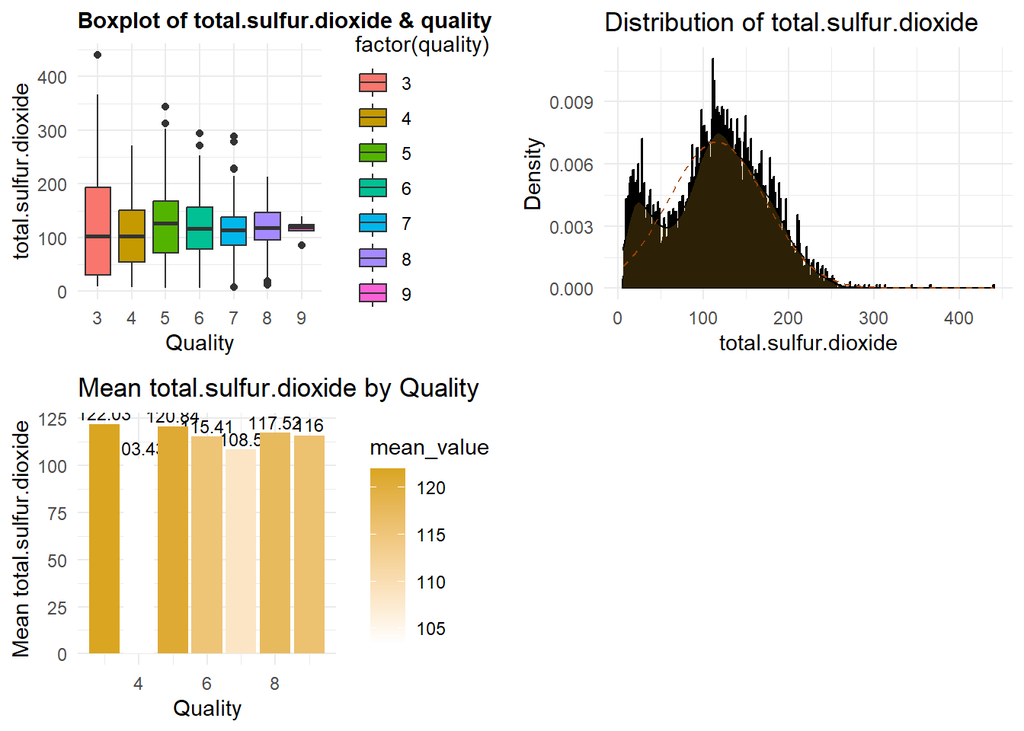

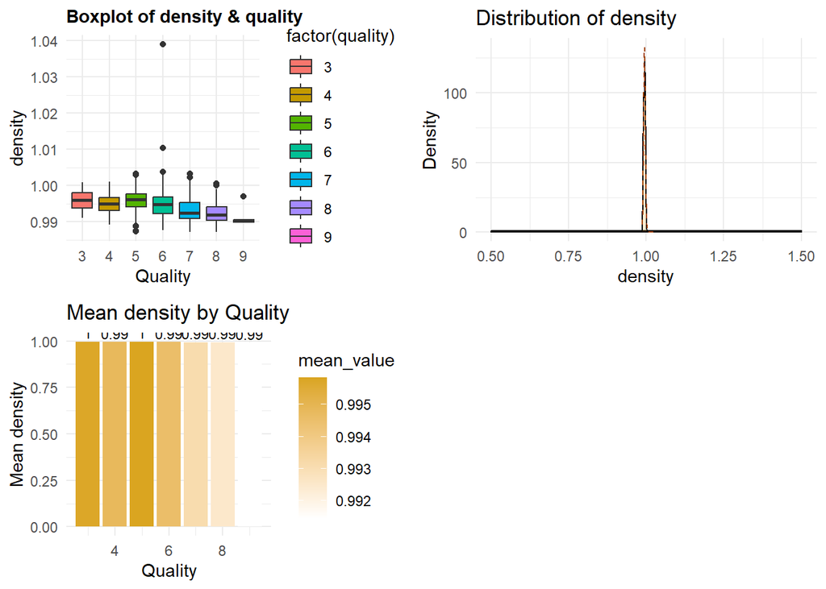

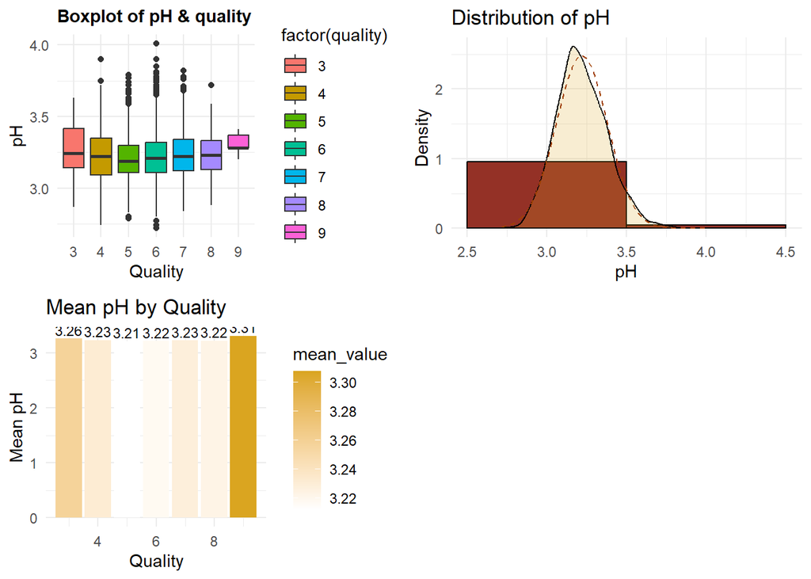

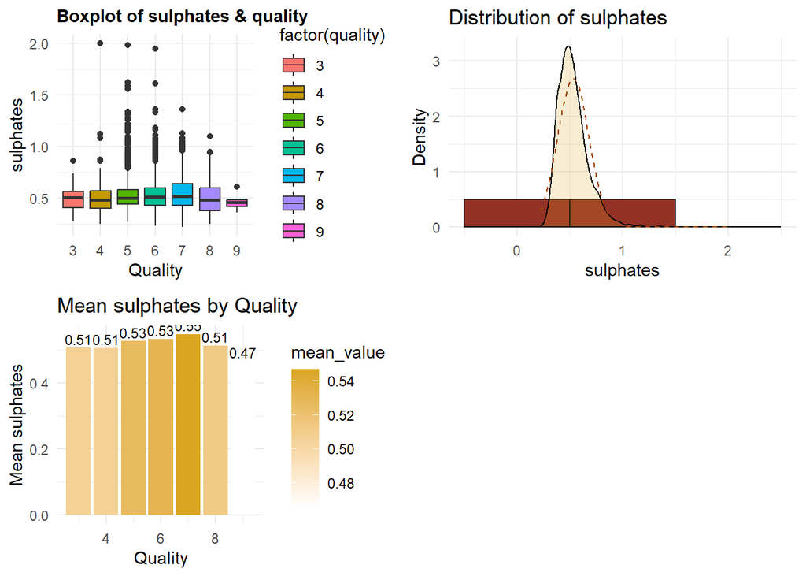

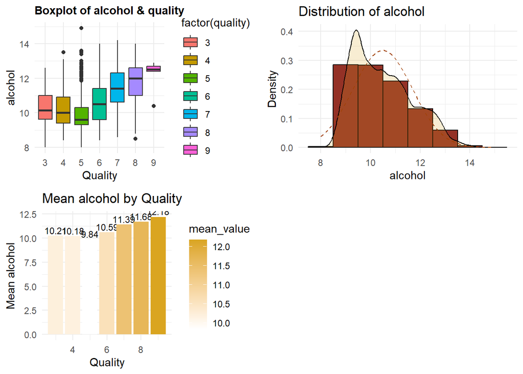

```r
library(ggplot2)
library(gridExtra)
library(dplyr)
columns_to_plot <- c("fixed.acidity", "volatile.acidity", "citric.acid", "residual.sugar",
                     "chlorides", "free.sulfur.dioxide", "total.sulfur.dioxide",
                     "density", "pH", "sulphates", "alcohol")

precomputed_stats <- lapply(columns_to_plot, function(column_name) {
  list(
    mean_sd = wine.df %>%
      summarise(mean = mean(get(column_name), na.rm = TRUE),
                sd = sd(get(column_name), na.rm = TRUE)),
    summary_by_quality = wine.df %>%
      group_by(quality) %>%
      summarise(mean_value = mean(get(column_name), na.rm = TRUE)) %>%
      arrange(quality)
  )
})

create_plots <- function(column_name, stats) {
  box_plot <- ggplot(wine.df, aes(x = factor(quality), y = .data[[column_name]])) +
    geom_boxplot(aes(fill = factor(quality))) +
    labs(title = paste("Boxplot of", column_name, "& quality"), x = "Quality", y = column_name) +
    theme_minimal() +
    theme(plot.title = element_text(color = "black", size = 11, face = "bold"))

  dist_plot <- ggplot(wine.df, aes(x = .data[[column_name]])) +
    geom_histogram(aes(y = ..density..), binwidth = 1, fill = "#943126", color = "black") +
    geom_density(alpha = .2, fill = "#DAA520") +
    stat_function(fun = dnorm, args = with(stats$mean_sd, list(mean = mean, sd = sd)),
                  color = "#A04000", linetype = "dashed") +
    labs(title = paste("Distribution of", column_name), x = column_name, y = "Density") +
    theme_minimal()

  bar_plot <- ggplot(stats$summary_by_quality, aes(x = quality, y = mean_value, fill = mean_value)) +
    geom_text(aes(label = round(mean_value, 2)), vjust = -0.3, size = 3) +
    geom_col() +
    scale_fill_gradient(low = "white", high = "#DAA520") +
    theme_minimal() +
    labs(title = paste("Mean", column_name, "by Quality"), x = "Quality", y = paste("Mean", column_name))

  grid.arrange(box_plot, dist_plot, bar_plot, nrow = 2, ncol = 2)
}

plot_list <- mapply(create_plots, columns_to_plot, precomputed_stats, SIMPLIFY = FALSE, USE.NAMES = TRUE)
```

```r
for (name in names(plot_list)) {
  print(plot_list[[name]])
}
```

[output not shown]

First of all generally we can see a lot of outlier. Let’s consider how each category is related to Quality and deal with the outliers.

**fixed acidity** Fixed acidity may not have much effect on splitting votes.

On the second graph, we see that there is a skewness to the right. We need to fix this.

**volatile acidity** The decrease in volatile acidity seems to affect the votes positively.

**citric acid** We can say that the increase in citric acid affects the votes positively.

**residual sugar** The estimate of residual sugar does not seem to have much effect.

We see that there is a skewness towards the right according to the normal distribution

**chlorides** We see that the decrease in chlorides has a positive effect on the votes..

**free sulfur dioxide** When we examine the gariks here, we see that the graph is tailing to the right, we will correct this below.

**total sulfur dioxide** When we examine these graphs, we do not see that they have a regular effect on the target variable. It is not easy to draw conclusions.

Here we see a skewness to the right.

**density** It seems quite difficult to predict the effect on the target variable.

When we examine the scatterplot, we see that it has a normal distribution.

We see that the scatterplot has normal, outlier values. We need to identify and remove outliers.

**alcohol** When the graph is examined in general, it can be said that the increase in alcohol has a positive effect on the votes.

When we examine the second graph, we see that there is skewness. We will fix this.

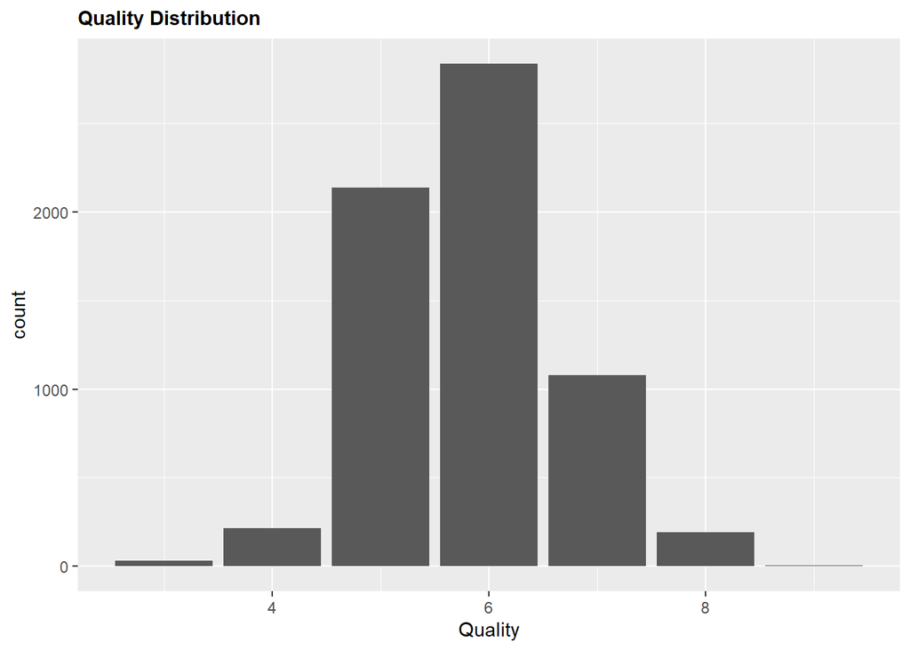

```r
ggplot(wine.df, aes(x = quality)) +
  geom_bar() +
  xlab("Quality") +
  ggtitle("Quality Distribution") +
  theme(plot.title = element_text(color = "black", size = 11, face = "bold"))
```

[figure not shown]

```r
quality_counts <- table(wine.df$quality)
quality_labels <- names(quality_counts)
quality_percent <- round(100 * quality_counts / sum(quality_counts), 2)

explode <- rep(0.1, length(quality_counts))

cum_percents <- cumsum(quality_counts) / sum(quality_counts)
label_positions <- cum_percents - quality_counts / sum(quality_counts) / 2

label_radius <- 1.2
label_x <- cos(2 * pi * label_positions) * label_radius
label_y <- sin(2 * pi * label_positions) * label_radius

pie(quality_counts, labels = NA, col = rainbow(length(quality_counts)),
    main = "Quality Distribution", init.angle = 60, radius = 1)
legend("topright", legend = quality_labels, fill = rainbow(length(quality_labels)))


text(label_x, label_y, labels = paste(quality_labels, ": ", quality_percent, "%", sep = ""))

legend("topright", legend = quality_labels, fill = rainbow(length(quality_labels)))
```

```r
labels = paste(quality_labels, ": ", quality_percent, "%", sep = "")
```

Our dataset appears to have a significant class imbalance, especially with very few data points for quality ratings of 9 ,3. Class imbalance can lead to models that are biased towards the majority class. Thus we will use method such as resampling, providing class weights, ensemble methods to slove the imbalance problem. Moreover, with the outliers we will consider how to deal with after fix the skewness in the data.

### Skewness Correction

In this section, we will try to correct the skewness in some features of our data. We will do this by seeing them through graphs.

fixed acidity, residual sugar ,free sulfur dioxide, total sulfur dioxide, sulphates

```r
# Skewness Correction

library(MASS)
library(car)
### fixed acidity
mu <- mean(wine.df$`fixed.acidity`, na.rm = TRUE)
sigma <- sd(wine.df$`fixed.acidity`, na.rm = TRUE)
cat(sprintf("mu fixed acidity: %f, sigma fixed acidity: %f\n", mu, sigma))
```

```
## mu fixed acidity: 7.215307, sigma fixed acidity: 1.296434
```

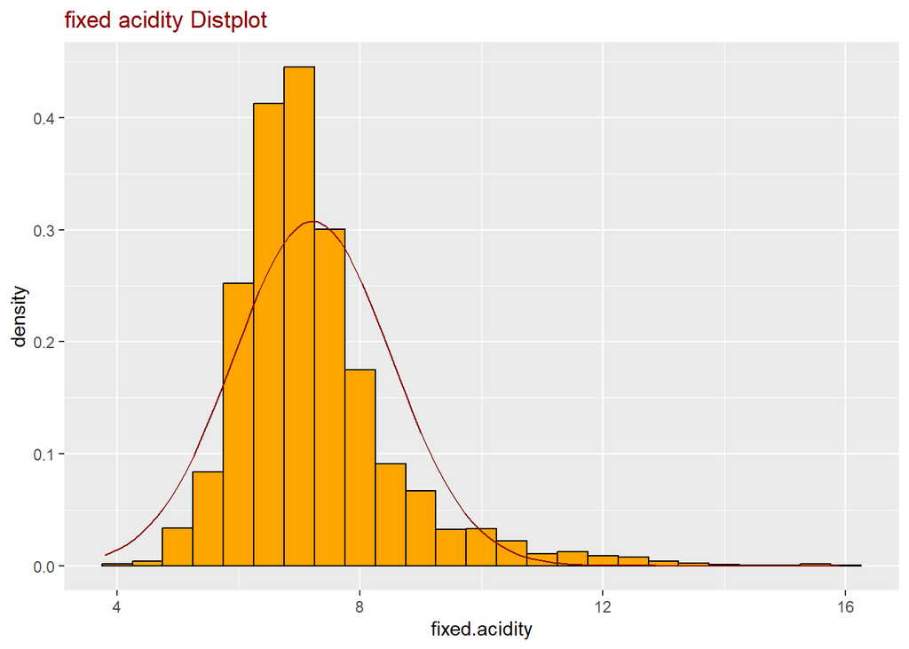

```r
ggplot(wine.df, aes(x = `fixed.acidity`)) +
  geom_histogram(aes(y = ..density..), binwidth = 0.5, fill = "orange", color = "black") +
  stat_function(fun = dnorm, args = list(mean = mu, sd = sigma), color = "darkred") +
  ggtitle("fixed acidity Distplot") +
  theme(plot.title = element_text(color = "darkred"))
```

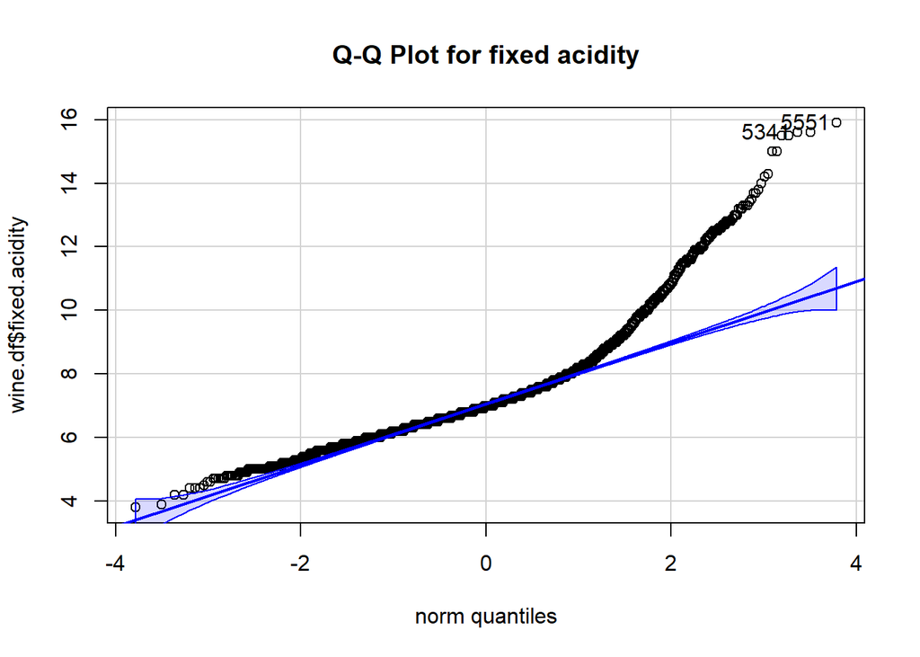

```
## [1] 5551 5341
```

```r
qqPlot(wine.df$`fixed.acidity`, main = "Q-Q Plot for fixed acidity")
```

```r
# Log Transformation
if (all(wine.df$`fixed.acidity` > 0)) {
  wine.df$`fixed.acidity` <- log(wine.df$`fixed.acidity`)
} else {
  stop("Log transformation requires all values to be positive.")
}

mu_transformed <- mean(wine.df$`fixed.acidity`, na.rm = TRUE)
sigma_transformed <- sd(wine.df$`fixed.acidity`, na.rm = TRUE)
cat(sprintf("Transformed mu fixed.acidity: %f, sigma fixed.acidity: %f\n", mu_transformed, sigma_transformed))
```

```
## Transformed mu fixed.acidity: 1.962001, sigma fixed.acidity: 0.164255
```

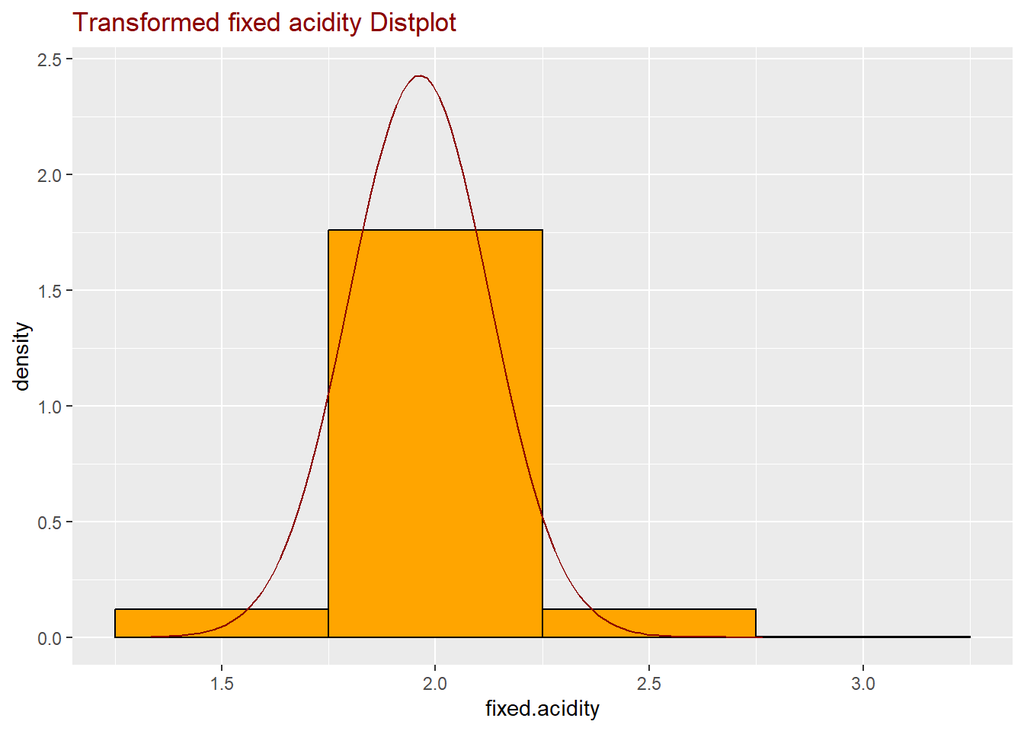

```r
# after transformation
par(mfrow = c(1, 2))
ggplot(wine.df, aes(x = `fixed.acidity`)) +
  geom_histogram(aes(y = ..density..), binwidth = 0.5, fill = "orange", color = "black") +
  stat_function(fun = dnorm, args = list(mean = mu_transformed, sd = sigma_transformed), color = "darkred") +
  ggtitle("Transformed fixed acidity Distplot") +
  theme(plot.title = element_text(color = "darkred"))
```

```
## [1] 5551 5341
```

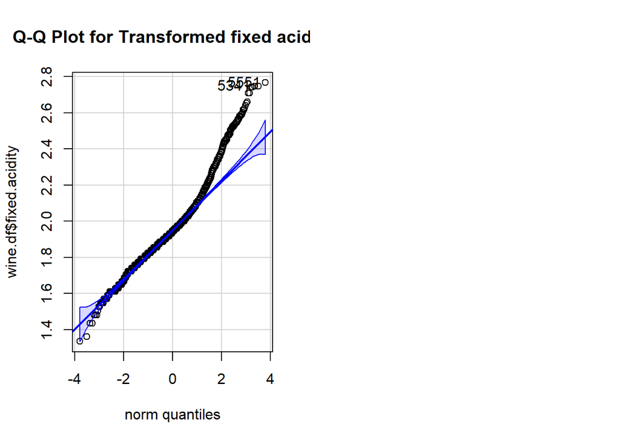

```r
qqPlot(wine.df$`fixed.acidity`, main = "Q-Q Plot for Transformed fixed acidity")
```

```r
### residual sugar
mu <- mean(wine.df$`residual.sugar`, na.rm = TRUE)
sigma <- sd(wine.df$`residual.sugar`, na.rm = TRUE)
cat(sprintf("mu residual sugar: %f, sigma residual sugar: %f\n", mu, sigma))
```

```
## mu residual sugar: 5.443235, sigma residual sugar: 4.757804
```

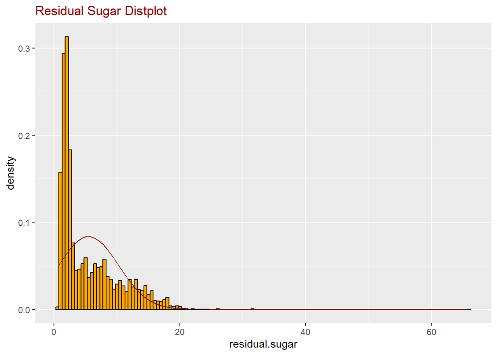

```r
par(mfrow = c(1, 2))
ggplot(wine.df, aes(x = `residual.sugar`)) +
  geom_histogram(aes(y = ..density..), binwidth = 0.5, fill = "orange", color = "black") +
  stat_function(fun = dnorm, args = list(mean = mu, sd = sigma), color = "darkred") +
  ggtitle("Residual Sugar Distplot") +
  theme(plot.title = element_text(color = "darkred"))
```

```
## [1] 2782 1654
```

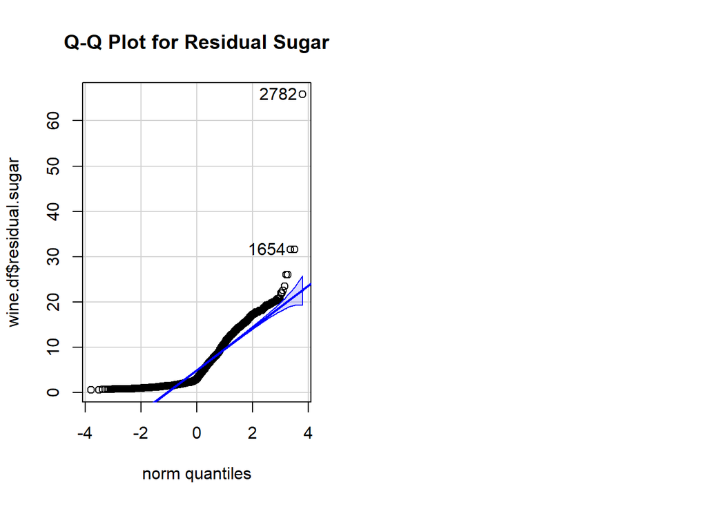

```r
qqPlot(wine.df$`residual.sugar`, main = "Q-Q Plot for Residual Sugar")
```

```r
# Log Transformation
if (all(wine.df$`residual.sugar` > 0)) {
  wine.df$`residual.sugar` <- log(wine.df$`residual.sugar`)
} else {
  stop("Log transformation requires all values to be positive.")
}
mu_transformed <- mean(wine.df$`residual.sugar`, na.rm = TRUE)
sigma_transformed <- sd(wine.df$`residual.sugar`, na.rm = TRUE)
cat(sprintf("Transformed mu residual sugar: %f, sigma residual sugar: %f\n", mu_transformed, sigma_transformed))
```

```
## Transformed mu residual sugar: 1.325705, sigma residual sugar: 0.863555
```

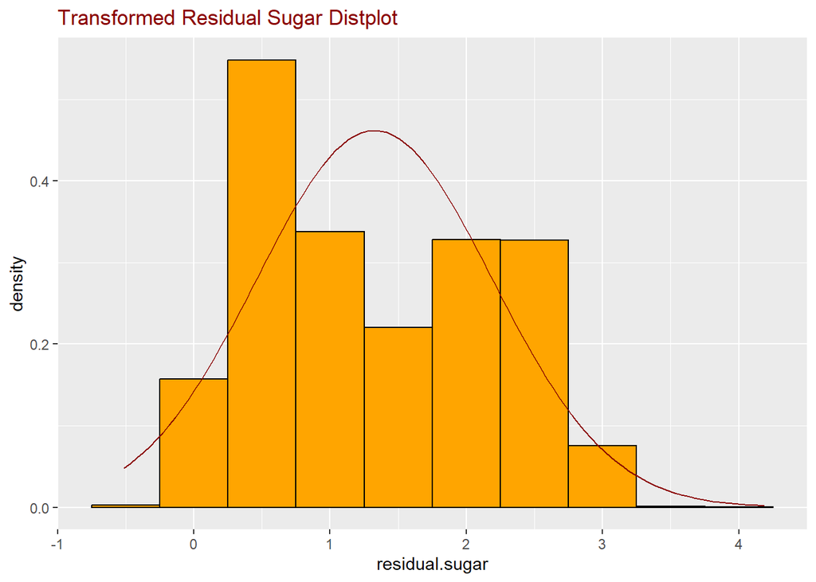

```r
par(mfrow = c(1, 2))
ggplot(wine.df, aes(x = `residual.sugar`)) +
  geom_histogram(aes(y = ..density..), binwidth = 0.5, fill = "orange", color = "black") +
  stat_function(fun = dnorm, args = list(mean = mu_transformed, sd = sigma_transformed), color = "darkred") +
  ggtitle("Transformed Residual Sugar Distplot") +
  theme(plot.title = element_text(color = "darkred"))
```

```
## [1] 2782 1654
```

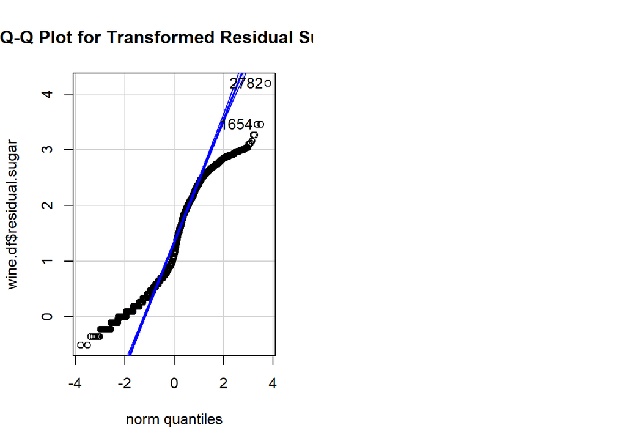

```r
qqPlot(wine.df$`residual.sugar`, main = "Q-Q Plot for Transformed Residual Sugar")
```

```r
### free sulfur dioxide
mu <- mean(wine.df$`free.sulfur.dioxide`, na.rm = TRUE)
sigma <- sd(wine.df$`free.sulfur.dioxide`, na.rm = TRUE)
cat(sprintf("mu free sulfur dioxide: %f, sigma free sulfur dioxide: %f\n", mu, sigma))
```

```
## mu free sulfur dioxide: 30.525319, sigma free sulfur dioxide: 17.749400
```

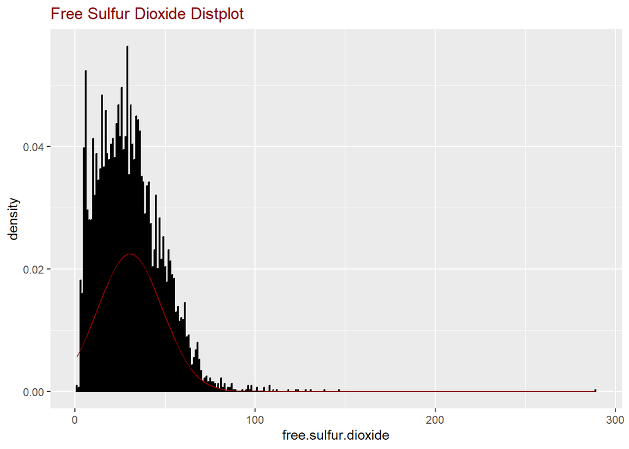

```r
par(mfrow = c(1, 2))
ggplot(wine.df, aes(x = `free.sulfur.dioxide`)) +
  geom_histogram(aes(y = ..density..), binwidth = 0.5, fill = "orange", color = "black") +
  stat_function(fun = dnorm, args = list(mean = mu, sd = sigma), color = "darkred") +
  ggtitle("Free Sulfur Dioxide Distplot") +
  theme(plot.title = element_text(color = "darkred"))
```

```
## [1] 4746 1932
```

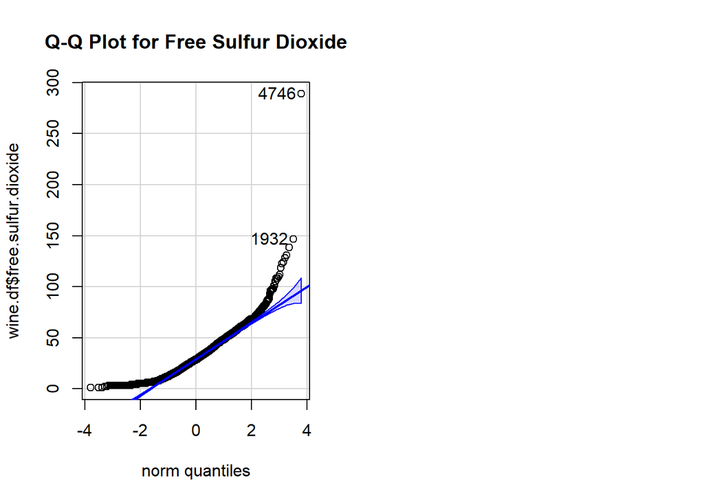

```r
qqPlot(wine.df$`free.sulfur.dioxide`, main = "Q-Q Plot for Free Sulfur Dioxide")
```

```r
if (all(wine.df$`free.sulfur.dioxide` > 0)) {
  wine.df$`free.sulfur.dioxide` <- log(wine.df$`free.sulfur.dioxide`)
} else {
  stop("Log transformation requires all values to be positive.")
}
mu_transformed <- mean(wine.df$`free.sulfur.dioxide`, na.rm = TRUE)
sigma_transformed <- sd(wine.df$`free.sulfur.dioxide`, na.rm = TRUE)
cat(sprintf("Transformed mu free sulfur dioxide: %f, sigma free sulfur dioxide: %f\n", mu_transformed, sigma_transformed))
```

```
## Transformed mu free sulfur dioxide: 3.216126, sigma free sulfur dioxide: 0.698635
```

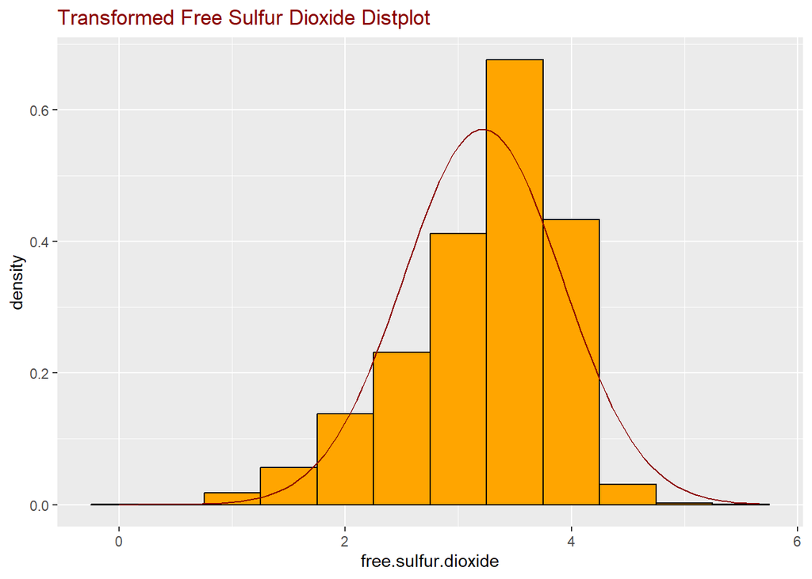

```r
par(mfrow = c(1, 2))
ggplot(wine.df, aes(x = `free.sulfur.dioxide`)) +
  geom_histogram(aes(y = ..density..), binwidth = 0.5, fill = "orange", color = "black") +
  stat_function(fun = dnorm, args = list(mean = mu_transformed, sd = sigma_transformed), color = "darkred") +
  ggtitle("Transformed Free Sulfur Dioxide Distplot") +
  theme(plot.title = element_text(color = "darkred"))
```

```
## [1] 5429 5434
```

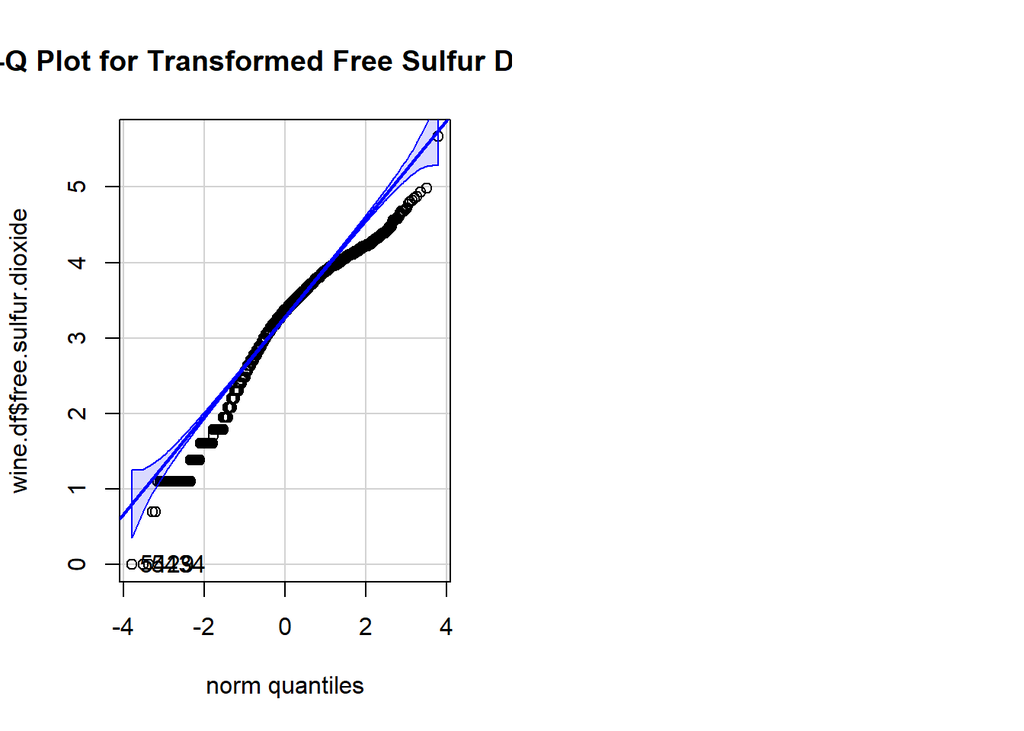

```r
qqPlot(wine.df$`free.sulfur.dioxide`, main = "Q-Q Plot for Transformed Free Sulfur Dioxide")
```

```r
### total sulfur dioxide
mu <- mean(wine.df$`total.sulfur.dioxide`, na.rm = TRUE)
sigma <- sd(wine.df$`total.sulfur.dioxide`, na.rm = TRUE)
cat(sprintf("mu total sulfur dioxide: %f, sigma total sulfur dioxide: %f\n", mu, sigma))
```

```
## mu total sulfur dioxide: 115.744574, sigma total sulfur dioxide: 56.521855
```

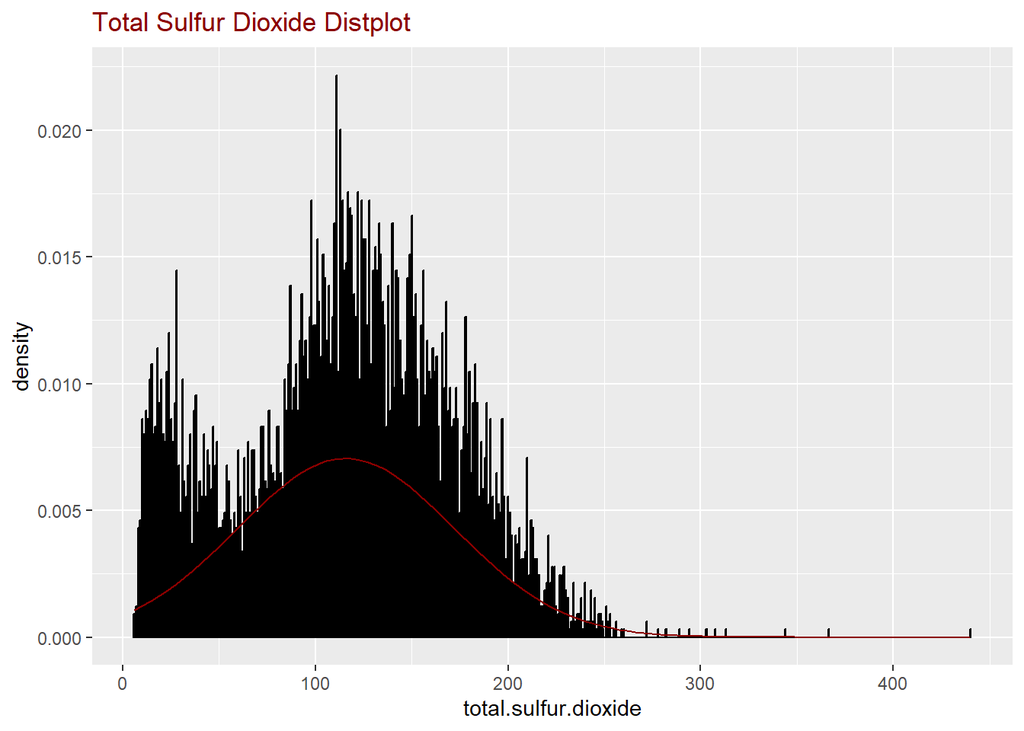

```r
par(mfrow = c(1, 2))
ggplot(wine.df, aes(x = `total.sulfur.dioxide`)) +
  geom_histogram(aes(y = ..density..), binwidth = 0.5, fill = "orange", color = "black") +
  stat_function(fun = dnorm, args = list(mean = mu, sd = sigma), color = "darkred") +
  ggtitle("Total Sulfur Dioxide Distplot") +
  theme(plot.title = element_text(color = "darkred"))
```